# Fitting a Multinomial Logistic Regression Model to Fetal Health Data

Andrew Disher

2023-08-19

**This document records my exploration of the fetal health data set, available here: [Fetal Health data from Kaggle](https://www.kaggle.com/datasets/andrewmvd/fetal-health-classification). Our modeling goal is to fit a logistic regression model to accurately predict the health of a fetus in the time leading up to child birth.**

### Goals of this Project

1. Practice fitting the multinomial logistic regression model
2. Practice balancing data sets via over/under-sampling class stratified observations
3. Applying Principal Component Analysis (PCA) to a set of predictors/features
4. Use visualizations and computed metrics to assess model fit
5. Practice using the box package for explicit package and function dependencies (instead of using library() calls)

### Traversing this Document

To quickly travel to a specific numbered section of this document, you can click on one of the section links provided on the left-hand side of the page.

This is a lengthy document, and I wanted to make it as pleasant as possible for the reader (you) to explore my work.

Enjoy!

### Some Setup

In case you are downloading this project from GitHub to explore it yourself, note that it uses the [renv](https://rstudio.github.io/renv/articles/renv.html) R package. This is to manage the dependencies of the project to ensure that all needed packages, the packages they depend on, and their correct versions are installed. If you have never used renv before, simply follow these steps once you’ve loaded the project in an R session:

In you R console, run the command `renv::restore(clean = TRUE)`. This will install the required R dependencies, recorded in the file renv.lock, to run the project code.

After that, you’re good to go!

### 1) Import necessary packages

Instead of using traditional R `library()` calls, we’ll use the `box` package. What this package does is essentially the same as `library()`, except that we are now able to specify which functions we require in our import statements. This ensures we are not importing functions we don’t need, and has the added benefit of letting us know which package is providing us with which functions.

The syntax for this is of the form `box::use(<package1>[<function>], <package2>[<function1>, <function2>, ...])`. If you’ve never used box before, I highly recommend it. You can learn more on the [box package website](https://klmr.me/box/articles/box.html) if you have never used this method.

```r
box::use(
  caret[confusionMatrix],
  dplyr[`%>%`, across, arrange, case_when, glimpse, group_by, mutate, n, summarize],
  ggcorrplot[cor_pmat, ggcorrplot],
  ggplot2[aes, coord_flip, element_text, geom_bar, geom_boxplot, geom_line, geom_point,
          geom_violin, ggplot, labs, scale_fill_viridis_d, scale_x_discrete, theme,
          theme_gray, theme_minimal],
  gt[gt],
  nnet[multinom],
  pROC[auc, multiclass.roc, plot.roc],
  ROSE[ovun.sample],
  tidyr[pivot_longer]
  )
```

### 2) Check the variable structure of the data set

First, I would like to know what variables I am dealing with and what are their types. The `glimpse()` function from dplyr is useful for this.

```r
Fetal_Health_Data_Set <- read.csv("data/fetal_health.csv")
glimpse(Fetal_Health_Data_Set)
```

```
## Rows: 2,126
## Columns: 22
## $ baseline.value                                         <dbl> 120, 132, 133, …
## $ accelerations                                          <dbl> 0.000, 0.006, 0…
## $ fetal_movement                                         <dbl> 0.000, 0.000, 0…
## $ uterine_contractions                                   <dbl> 0.000, 0.006, 0…
## $ light_decelerations                                    <dbl> 0.000, 0.003, 0…
## $ severe_decelerations                                   <dbl> 0, 0, 0, 0, 0, …
## $ prolongued_decelerations                               <dbl> 0.000, 0.000, 0…
## $ abnormal_short_term_variability                        <dbl> 73, 17, 16, 16,…
## $ mean_value_of_short_term_variability                   <dbl> 0.5, 2.1, 2.1, …
## $ percentage_of_time_with_abnormal_long_term_variability <dbl> 43, 0, 0, 0, 0,…
## $ mean_value_of_long_term_variability                    <dbl> 2.4, 10.4, 13.4…
## $ histogram_width                                        <dbl> 64, 130, 130, 1…
## $ histogram_min                                          <dbl> 62, 68, 68, 53,…
## $ histogram_max                                          <dbl> 126, 198, 198, …
## $ histogram_number_of_peaks                              <dbl> 2, 6, 5, 11, 9,…
## $ histogram_number_of_zeroes                             <dbl> 0, 1, 1, 0, 0, …
## $ histogram_mode                                         <dbl> 120, 141, 141, …
## $ histogram_mean                                         <dbl> 137, 136, 135, …
## $ histogram_median                                       <dbl> 121, 140, 138, …
## $ histogram_variance                                     <dbl> 73, 12, 13, 13,…
## $ histogram_tendency                                     <dbl> 1, 0, 0, 1, 1, …
## $ fetal_health                                           <dbl> 2, 1, 1, 1, 1, …
```

They are all continuous numeric variables. How nice!

Generally, I like to sort the variables to make my life easier with plotting, etc. We’ll sort the variables alphabetically.

```r
Fetal_Health_Data_Set <- Fetal_Health_Data_Set[, sort(colnames(Fetal_Health_Data_Set))]
```

### 3) Create training and testing data sets

Before diving into examining data, and then eventually modeling it, let’s create two data splits for training and testing data. We’ll use an 80-20 split; 80% training data and 20% testing data.

```r
# Split Data into Training and Testing
sample_size = floor(0.8*nrow(Fetal_Health_Data_Set))
set.seed(666)

# Randomly split data
picked = sample(seq_len(nrow(Fetal_Health_Data_Set)), size = sample_size)

# Store the Training and Testing data in their respective data frames
training_data <- Fetal_Health_Data_Set[picked, ]
test_data <- Fetal_Health_Data_Set[-picked, ]
```

I’d like to create a function to acquire some summary statistics, like mean, median etc., for each of the variables. The built in `summary.data.frame()` function could be used, but it’s output is not formatted very well, so we’ll use the function below:

```r
custom_summary <- function(data, cols) {
  data %>%
    pivot_longer(cols = all_of(cols), names_to = "Variable", values_to = "Value") %>%
    group_by(Variable) %>%
    arrange(Variable) %>%
    summarize(min = min(Value),
              max = max(Value),
              median = median(Value),
              mean = mean(Value),
              sd = sd(Value),
              n = n())
}
```

Let’s see what our custom summary looks like for our data set. We’ll pipe the output to `gt`’s `gt()` function to make it easier on the eyes in this markdown document. Note that I’m removing the `fetal_health` variable, since that is our categorical variable, which we’ll be investigating more in a bit.

```r
predictor_data <- subset(training_data, select = -c(fetal_health))

columns <- predictor_data %>%
  colnames()

custom_summary(data = training_data, cols = columns) %>%
  gt()
```

| Variable | min | max | median | mean | sd | n |
| --- | --- | --- | --- | --- | --- | --- |
| abnormal_short_term_variability | 12.0 | 86.000 | 49.000 | 4.718353e+01 | 1.710561e+01 | 1700 |
| accelerations | 0.0 | 0.018 | 0.002 | 3.171765e-03 | 3.830721e-03 | 1700 |
| baseline.value | 106.0 | 159.000 | 133.000 | 1.333359e+02 | 9.688473e+00 | 1700 |
| fetal_movement | 0.0 | 0.477 | 0.000 | 9.194706e-03 | 4.559139e-02 | 1700 |
| histogram_max | 122.0 | 238.000 | 162.000 | 1.639559e+02 | 1.766698e+01 | 1700 |
| histogram_mean | 75.0 | 182.000 | 136.000 | 1.346218e+02 | 1.526790e+01 | 1700 |
| histogram_median | 78.0 | 186.000 | 139.000 | 1.380688e+02 | 1.413479e+01 | 1700 |
| histogram_min | 50.0 | 159.000 | 93.000 | 9.357118e+01 | 2.961050e+01 | 1700 |
| histogram_mode | 60.0 | 186.000 | 139.000 | 1.375135e+02 | 1.593665e+01 | 1700 |
| histogram_number_of_peaks | 0.0 | 18.000 | 3.000 | 4.078235e+00 | 2.960859e+00 | 1700 |
| histogram_number_of_zeroes | 0.0 | 8.000 | 0.000 | 3.229412e-01 | 6.928990e-01 | 1700 |
| histogram_tendency | -1.0 | 1.000 | 0.000 | 3.229412e-01 | 6.136112e-01 | 1700 |
| histogram_variance | 0.0 | 269.000 | 7.000 | 1.851588e+01 | 2.856813e+01 | 1700 |
| histogram_width | 3.0 | 180.000 | 68.000 | 7.038471e+01 | 3.894498e+01 | 1700 |
| light_decelerations | 0.0 | 0.015 | 0.000 | 1.850000e-03 | 2.923263e-03 | 1700 |
| mean_value_of_long_term_variability | 0.0 | 50.700 | 7.400 | 8.276412e+00 | 5.731312e+00 | 1700 |
| mean_value_of_short_term_variability | 0.2 | 7.000 | 1.200 | 1.333000e+00 | 8.911106e-01 | 1700 |
| percentage_of_time_with_abnormal_long_term_variability | 0.0 | 91.000 | 0.000 | 9.958235e+00 | 1.840206e+01 | 1700 |
| prolongued_decelerations | 0.0 | 0.005 | 0.000 | 1.517647e-04 | 5.806598e-04 | 1700 |
| severe_decelerations | 0.0 | 0.001 | 0.000 | 4.117647e-06 | 6.405549e-05 | 1700 |
| uterine_contractions | 0.0 | 0.015 | 0.004 | 4.364706e-03 | 2.952227e-03 | 1700 |

It looks like most of our variables are within a positive range of values. This makes sense though, because a lot of them are attributes measured from the histogram displayed from the tool used monitor fetal health (the Cardiotocogram, or CTG). Also, any variables that measure things like `number of peaks`, `number of zeros`, and `histogram variance` will inherently have values greater or equal to zero. They will never be negative.

### 4) Visualizing the data

Let’s create some boxplots plots to better understand these predictor variables. I’ll also rename these variables so the original variable names don’t clutter the plot, since they are super long!

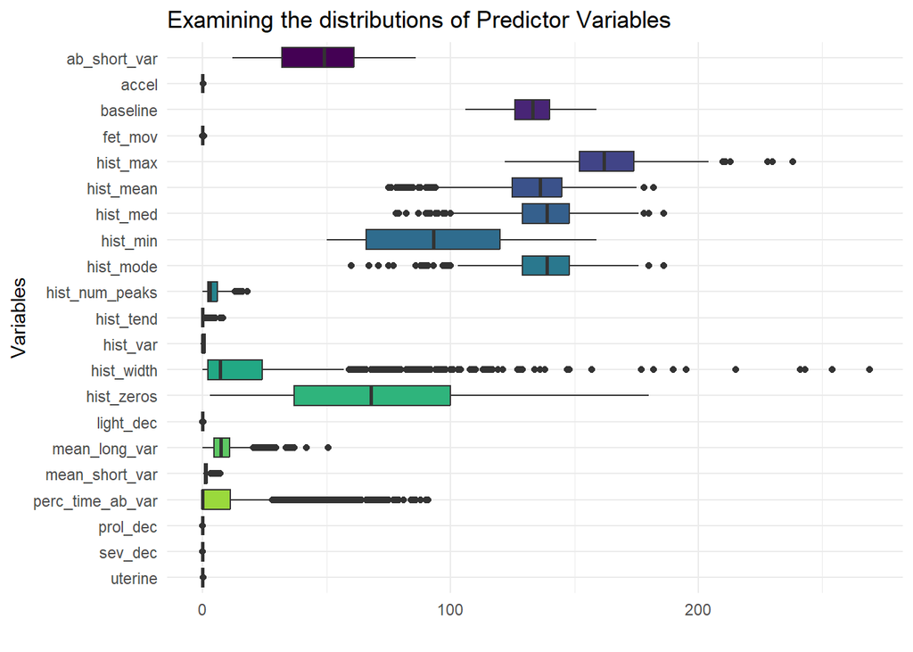

```r
# Renaming the predictor variable columns
colnames(predictor_data) <- sort(c("baseline", 'accel', "fet_mov", "uterine", "light_dec", "sev_dec",
                                   "prol_dec", "ab_short_var", "mean_short_var", "perc_time_ab_var",
                                   "mean_long_var", "hist_width", "hist_min", "hist_max", "hist_num_peaks",
                                   "hist_zeros", "hist_mode", "hist_mean", "hist_med",
                                   "hist_var", "hist_tend"))
# Create the boxplots
predictor_data %>%
  pivot_longer(names_to = "Variable",
               values_to = "Value",
               cols = all_of(colnames(predictor_data))) %>%
  ggplot(aes(x = Variable, y = Value, fill = Variable)) +
  geom_boxplot() +
  scale_x_discrete(limits = rev(colnames(predictor_data))) +
  scale_fill_viridis_d() +
  labs(title = "Examining the distributions of Predictor Variables",
       x = "Variables",
       y = "") +
  coord_flip() +
  theme_minimal() +
  theme(legend.position = "none")
```

The first thing that jumps out is that we have many `"apparent"` outliers, for a number of variables. Secondly, the construction of this chart is not as useful as it could be. Lets standardize each of these variables such that they can be compared on the same scale.

We’ll do this by using the `scale()` function from base R, which subtracts a variable’s mean from each observation and then divides by the variable’s standard deviation. This will cause each variable to have a mean of zero and a standard deviation of 1.

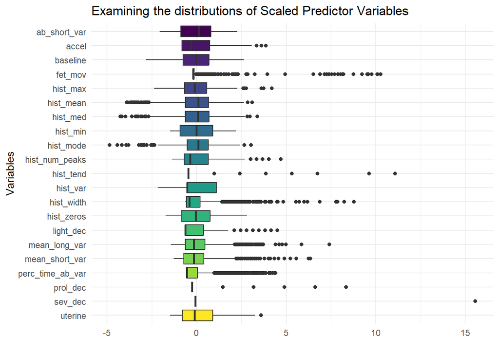

```r
# Scale each of the predictors
scaled_predictors <- predictor_data %>%
  mutate(across(all_of(colnames(predictor_data)), scale))

# Plot scaled predictors
scaled_predictors %>%
  pivot_longer(names_to = "Variable",
               values_to = "Value",
               cols = all_of(colnames(scaled_predictors))) %>%
  ggplot(aes(x = Variable, y = Value, fill = Variable)) +
  geom_boxplot() +
  scale_x_discrete(limits = rev(colnames(scaled_predictors))) +
  scale_fill_viridis_d() +
  labs(title = "Examining the distributions of Scaled Predictor Variables",
       x = "Variables",
       y = "") +
  coord_flip() +
  theme_minimal() +
  theme(legend.position = "none")
```

Nice! We can see each of the variables on the same scale now. Like before, we see many outliers, however now we can see the general number of outliers for variables with much smaller scales, like `accelerations` and `fetal_movement`.

### 5) Notes on Outliers

It’s easy to create some boxplots and determine that we have many outliers when many data points lay outside the bounds set by our classic 1.5*Interquartile Range (IQR) rule. However, this would be a mistake. There is no reason to believe these are genuine outliers. As far as we know, there were no measurement failures or something similar. The data set description on Kaggle gives no disclaimer about this detail.

Additionally, the IQR rule mentioned above is derived from the assumption that our distribution is a normal distribution, and is why the rule is a symmetric rule. The value 1.5 was chosen as a good boundary value to identify *potentional* outliers from this common distribution, but it doesn’t really apply for other distributions, which our predictor variables definitely belong to. If we made a violin plot for each of them, this would be much clearer. However, this is not done here because the shapes of these distributions take up a lot of space and it would be difficult to display them concisely, like we did with the boxplots.

Therefore, we must conclude that these extreme data points are simply natural occurences in the data. They are part of the naturally formed distribution. These distributions for the predictor variables are certainly non-normal, but that’s completely ok. They don’t have to be for our model!

All we care about is the multinomial distribution of the response variable, fetal_health. We’ll talk about that more soon.

### 6) Examining potential collinearity in predictors

Another common practice is to check if any of our predictors are correlated with each other. If they are, the estimates for our predictor coefficients might be inaccurate. To check this, let’s create a correlation matrix. We’ll display only the lower half, since the matrix is by definition symmetric.

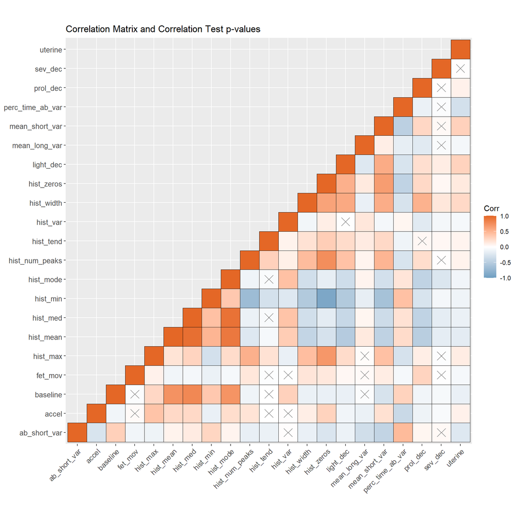

```r
ggcorrplot(corr = cor(predictor_data),
           type = "lower",
           show.diag = TRUE,
           outline.col = "black",
           ggtheme = theme_gray,
           colors = c("#6D9EC1", "white", "#E46726"),
           p.mat = cor_pmat(predictor_data),
           tl.cex = 10,
           title = "Correlation Matrix and Correlation Test p-values")
```

Oof! It seems like some variables tend to be highly correlated with others, especially the ones pertaining to the histogram coming from the cardiotocograms. The matrix above shows the correlations between the variables and displays an `X` over insignificant correlation cells. Significance was calculated using a correlation test with the function argument `p.mat`.

Let’s also display the correlations themselves, just for completeness.

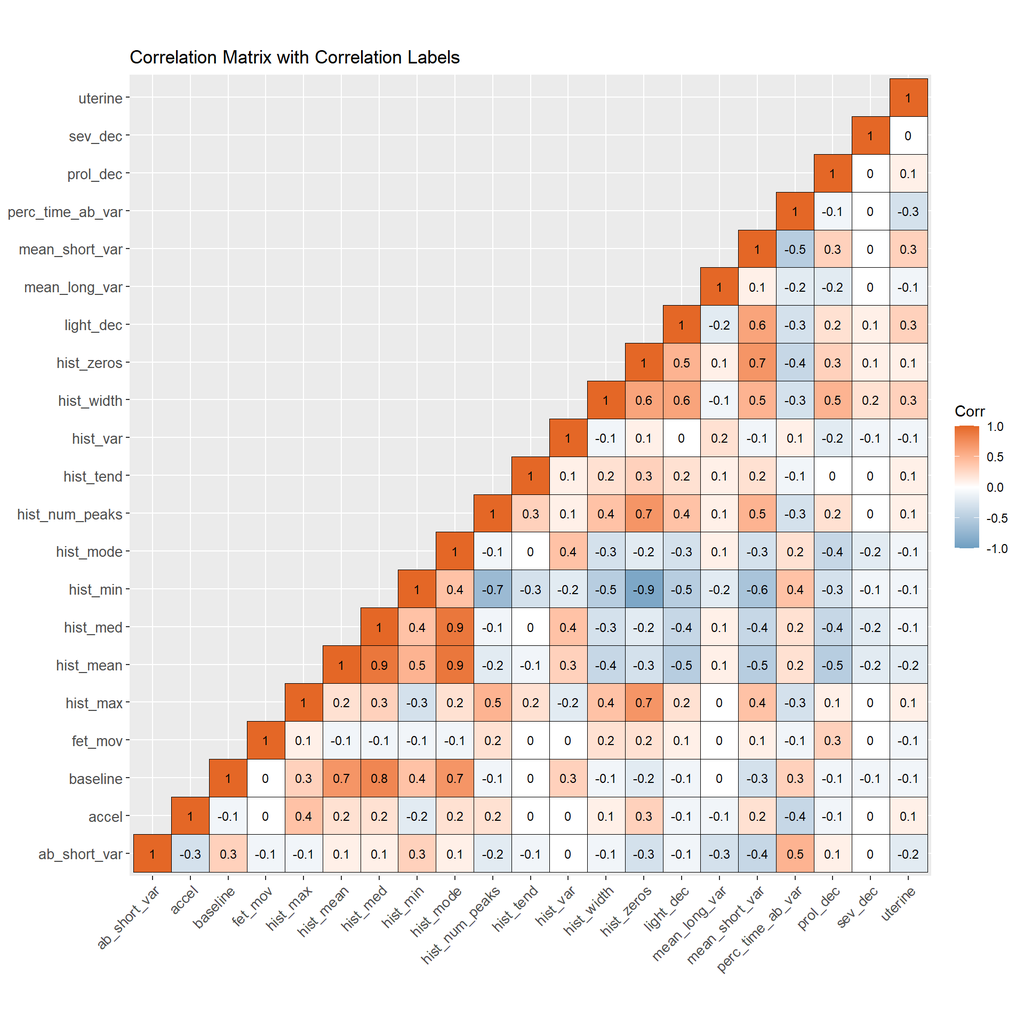

```r
ggcorrplot(corr = cor(predictor_data),
           type = "lower",
           show.diag = TRUE,
           outline.col = "black",
           ggtheme = theme_gray,
           colors = c("#6D9EC1", "white", "#E46726"),
           lab = TRUE,
           digits = 1,
           lab_size = 3,
           show.legend = TRUE,
           tl.cex = 10,
           title = "Correlation Matrix with Correlation Labels")
```

It seems like a dimensionality reduction technique may be necessary. However, there are tradeoffs with these techniques. Applying Principal Component Analysis (PCA) or something similar would erase any interpretation of coefficient estimates that we get from the final model. On the other hand, if we don’t apply one of these dimensionality reduction techniques, our model may not produce accurate coefficient estimates anyways.

It may be worth implementing PCA, but first we’ll have to address our imbalanced classes. Let’s do that now!

### 7) Exploring the response variable: fetal_health

fetal_health is a categorical variable with three levels:

1. Normal
2. Suspect (potential health complications)
3. Pathological (multiple signs point to definite health complications)

A natural first step is to examine the distribution of these classifications in the data. To do this, we create a table of proportions using the training_data.

```r
prop.table(table(training_data$fetal_health))
```

```
##
##          1          2          3
## 0.78000000 0.13882353 0.08117647
```

Wow! Now that is some imbalanced data. Class imbalance is a big issue that appears in many classification data sets. It’s something that occurs naturally, especially when we are trying to classify rare events. Most fetal development goes smoothly, thanks to modern medicine and widely available health care. But, there will always be cases for concern, which is exactly what we aim to classify accurately in this project.

To create an unbiased model, we have to correct for this class imbalance. There are multiple ways to address this issue:

- Undersample the commonly occurring class/level (Normal, in our case)
- Oversample the rare class (Suspect and Pathological)
- or a combination of both.

In this project, I chose to use a combination of both using a great package called `ROSE`, which provides the function `ovun.sample()`.

There is also the added complexity of having a categorical response variable with more than two classes. This makes our over-under sampling methodology more complex too.

Since we have three classes, we’ll create 2 subsets for our data:

- Subset containing observations belonging to classes 1 and 2 and
- Subset containing observations belonging to classes 1 and 3.

```r
subset12 <- base::subset(training_data, fetal_health == 1 | fetal_health == 2)

subset13 <- base::subset(training_data, fetal_health == 1 | fetal_health == 3)
```

Now, it is possible to undersample from class 1 in both cases and oversample from classes 2 and 3 in their respective subsets. Class 1 is shared because it is the most populous class.

#### Balancing Subset 1

```r
training_data12 <- ovun.sample(fetal_health~., data=subset12, method = "both",
                             p = 0.47, # Probability of resampling from the rare class (has heart disease)
                             seed = 666,
                             N = nrow(subset12))$data
```

#### Balancing Subset 2

```r
training_data13 <- ovun.sample(fetal_health~., data=subset13, method = "both",
                               p = 0.47, # Probability of resampling from the rare class (has heart disease)
                               seed = 666,
                               N = nrow(subset13))$data
```

We chose .47 as our probablity to sample from the rare class in both cases. It’s a little more conservative to do it this way, instead of choosing a 50-50 split. This was just my preference.

Let’s check the distribution of the response variable again, for both subsets.

```r
prop.table(table(training_data12$fetal_health))
```

```
##
##         1         2
## 0.5192061 0.4807939
```

```r
prop.table(table(training_data13$fetal_health))
```

```
##
##        1        3
## 0.522541 0.477459
```

Ok, very nice. We have now udnersampled from the observations belonging to class 1, and oversampled from classes 2 and 3. Our data is looking more balanced.

Now, we must obtain the union of these two sets, which also requires us to ensure that we **don’t** include the data from class 1 twice.

```r
training_data_balanced <- rbind(training_data12[training_data12$fetal_health == 2,], training_data13)

prop.table(table(training_data_balanced$fetal_health))
```

```
##
##         1         2         3
## 0.3453725 0.3390519 0.3155756
```

And there we go. Each class is represented by about a third of the observations within our training data set. Our imbalanced class issue has been rectified. Let’s move on to our PCA.

### 8) Principal Component Analysis

Let’s now use the `stats` function `prcomp()` to produce principal components for the predictor variables in our data set.

```r
predictor_data <- subset(training_data_balanced, select = -c(fetal_health))

# Remember to standardize the predictors. Neglecting this will skew the results of the PCA.
PCA_data <- prcomp(predictor_data, center = TRUE, scale. = TRUE)

summary(PCA_data)
```

```
## Importance of components:
##                           PC1    PC2     PC3     PC4     PC5     PC6     PC7
## Standard deviation     2.7897 1.7627 1.22576 1.17219 1.15356 0.98917 0.94052
## Proportion of Variance 0.3706 0.1480 0.07155 0.06543 0.06337 0.04659 0.04212
## Cumulative Proportion  0.3706 0.5185 0.59009 0.65552 0.71889 0.76548 0.80760
##                            PC8     PC9    PC10    PC11    PC12    PC13    PC14
## Standard deviation     0.90711 0.80670 0.72100 0.65301 0.62567 0.59685 0.51963
## Proportion of Variance 0.03918 0.03099 0.02475 0.02031 0.01864 0.01696 0.01286
## Cumulative Proportion  0.84679 0.87778 0.90253 0.92284 0.94148 0.95844 0.97130
##                           PC15    PC16    PC17    PC18    PC19    PC20
## Standard deviation     0.42292 0.37397 0.34933 0.30529 0.21784 0.14603
## Proportion of Variance 0.00852 0.00666 0.00581 0.00444 0.00226 0.00102
## Cumulative Proportion  0.97982 0.98648 0.99229 0.99672 0.99898 1.00000
##                             PC21
## Standard deviation     3.433e-15
## Proportion of Variance 0.000e+00
## Cumulative Proportion  1.000e+00
```

The principal components are listed above in order of importance. This order of importance is ranked according to how much of the total variation within the data each component can explain. We also see the cumulative variance proportion as we include more components. Often, it is not necessary to include more components after a threshold of 80% variance explained, in my experience.

We can also make a graph called a scree plot to apply the ‘elbow method’ to choose how many components to include in our model.

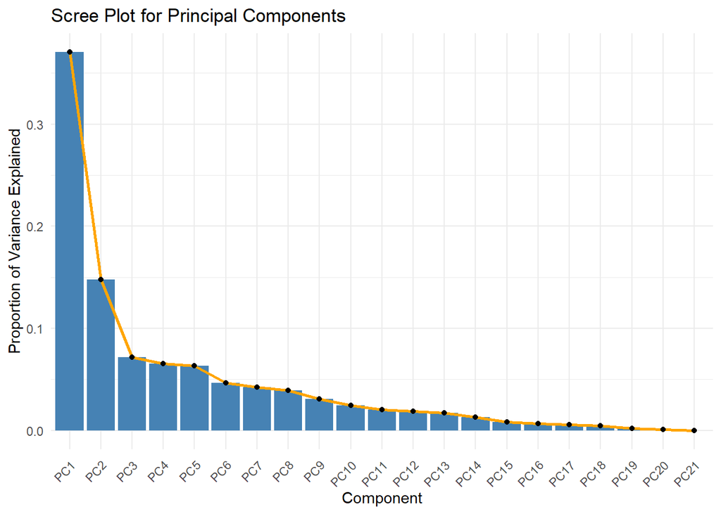

```r
# Data frame for plotting
pca_plotting <- data.frame(var_explained = PCA_data$sdev^2 / sum(PCA_data$sdev^2),
                           pc_names = (colnames(PCA_data$x)))

# Create the scree plot
ggplot(data = pca_plotting) +
  geom_bar(aes(x = reorder(pc_names, -var_explained), y = var_explained),
           stat = "identity", fill = "steel blue") +
  geom_line(aes(x = reorder(pc_names, -var_explained), y = var_explained, group = 1),
            color = "orange", linewidth = 1) +
  geom_point(aes(x = reorder(pc_names, -var_explained), y = var_explained),
             color = "black") +
  labs(title = "Scree Plot for Principal Components",
       y = "Proportion of Variance Explained",
       x = "Component") +
  theme_minimal() +
  theme(axis.text.x = element_text(angle = 45, vjust = 0.9, hjust=1))
```

We can see from this plot that the first principal component (by design) explains by far the most variance in the predictor data. The variance explained by other components continues to decrease, meaning that beyond a certain point, there is no reason to include any more of them. Using the elbow method, it is clear that including the first three components is enough, and any more yield diminshing returns.

The variance explained by the first three components is:

```r
pca_plotting$var_explained[1:3] %>%
  sum()
```

```
## [1] 0.59009
```

About 60%. That’s less than I would like, but let’s trust in the elbow method. We’ll use only the first three components in our model.

Now, let’s reassign our class labels to the principal component data we wish to use.

```r
# Bind the data
PCA_training_data <- cbind(PCA_data$x[, 1:3], training_data_balanced$fetal_health) %>%
  as.data.frame()

# Change the name of the fourth variable
colnames(PCA_training_data)[4] <- "fetal_health"
```

Lastly, let’s replace the 1’s, 2’s, and 3’s in the `fetal_health` column with their respective names and convert to a factor. Multinom expects a factor, and it would be nice to see the class names when we get our model ouput.

```r
# Convert values for fetal_health
PCA_training_data$fetal_health <- case_when(PCA_training_data$fetal_health == 1 ~ "Normal",
                                            PCA_training_data$fetal_health == 2 ~ "Suspect",
                                            PCA_training_data$fetal_health == 3 ~ "Pathological")

# multinom requires to response to be of class factor, so we'll quickly convert fetal_health
PCA_training_data$fetal_health <- as.factor(PCA_training_data$fetal_health)

# Display a data preview
PCA_training_data %>%
  head()
```

```
##            PC1         PC2        PC3 fetal_health
## 812 -0.2305721 -1.38857054 -0.4155372      Suspect
## 813 -2.1661352 -1.12038644 -0.3624603      Suspect
## 814 -1.9160225 -0.10412908  0.4734186      Suspect
## 815 -3.0869708 -1.69927033  0.9842526      Suspect
## 816 -2.7230532 -0.08285053  0.3316015      Suspect
## 817 -1.9160225 -0.10412908  0.4734186      Suspect
```

### 9) Fitting the Model

First, let’s create a model using only a constant intercept as a predictor. This will serve as our null/base model. We’ll use the `multinom()` function from the package `nnet`.

```r
model_null <- multinom(fetal_health ~ 1, data = PCA_training_data, model = TRUE)
summary(model_null)
```

```
## Call:
## multinom(formula = fetal_health ~ 1, data = PCA_training_data,
##     model = TRUE)
##
## Coefficients:
##              (Intercept)
## Pathological -0.09022541
## Suspect      -0.01846955
##
## Std. Errors:
##              (Intercept)
## Pathological  0.05232404
## Suspect       0.05136873
##
## Residual Deviance: 4863.551
## AIC: 4867.551
```

Now, let’s create a preliminary model for the training data, using the principal components as predictors.

```r
model1 <- multinom(fetal_health ~., data = PCA_training_data, model = TRUE)
summary(model1)
```

```
## Call:
## multinom(formula = fetal_health ~ ., data = PCA_training_data,
##     model = TRUE)
##
## Coefficients:
##              (Intercept)        PC1        PC2      PC3
## Pathological  -0.5794774  0.2648367 -2.1581662 2.274432
## Suspect        0.4998437 -0.2731050 -0.7119073 1.667295
##
## Std. Errors:
##              (Intercept)        PC1        PC2        PC3
## Pathological  0.12730511 0.04232352 0.09398599 0.12224700
## Suspect       0.09462893 0.03959918 0.05791843 0.09041258
##
## Residual Deviance: 2297.323
## AIC: 2313.323
```

We can see that the residual deviance for the null model is more than double that of the model using the principal components as predictors as well. This tells us that including them improves our model substantially. The AIC also greatly improves.

Let’s run an ANOVA to compare the two even more.

```r
anova(model_null, model1)
```

```
## Likelihood ratio tests of Multinomial Models
##
## Response: fetal_health
##             Model Resid. df Resid. Dev   Test    Df LR stat. Pr(Chi)
## 1               1      4428   4863.551
## 2 PC1 + PC2 + PC3      4422   2297.323 1 vs 2     6 2566.228       0
```

The chi-squared statistic of 2566 and it’s corresponding p-value of near-zero are evidence that the model improves dramatically over the null model, and that the principal components together are significant within the model. Unfortunately, we cannot interpret this much further, since PCA was used and the relationships between the original variables and the response variable, `fetal_health`, are now obscured.

### 10) Generating Predictions

Let’s try testing the model we fit using our test data set. One issue we have to address is that, well, our test data hasn’t been touched by our PCA step! That’s ok, the R prcomp object, produced by the function `prcomp()` can be used to transform our test predictors in the same we we had when we implemented the PCA with the training data.

Using a combination of the PCA_data object and the `predict()` function, we can use the rotation matrix from the PCA to do just that.

```r
PCA_test_data <- predict(PCA_data, newdata = subset(test_data, select = -c(fetal_health)))
```

Select the first 3 principal components, like before, and bind them to the test data response values.

```r
PCA_test_data <- cbind(PCA_test_data[, 1:3], test_data$fetal_health) %>%
  as.data.frame()

colnames(PCA_test_data)[4] <- "fetal_health"

PCA_test_data$fetal_health <- case_when(PCA_test_data$fetal_health == 1 ~ "Normal",
                                        PCA_test_data$fetal_health == 2 ~ "Suspect",
                                        PCA_test_data$fetal_health == 3 ~ "Pathological")
```

And examine our new test data frame.

```r
PCA_test_data %>%
    head()
```

```
##         PC1      PC2          PC3 fetal_health
## 3  1.960094 3.215520 -0.928929404       Normal
## 6  7.751418 1.161620  1.316006564 Pathological
## 14 0.607487 1.953037 -1.508809427       Normal
## 17 2.538369 2.766064  0.056338201       Normal
## 19 2.442514 1.482091  0.001919405       Normal
## 22 3.509062 1.995709  1.305205473       Normal
```

Ok! Now that our test data is ready, let’s calcualte some actual predictions using the model.

```r
predictions <- predict(model1, newdata = PCA_test_data[, 1:3])
```

### 11) Model Evaluation: Confusion Matrix

And now create a confusion matrix for us to evaluate our model with.

```r
conf_matrix <- confusionMatrix(data = predictions, reference = as.factor(PCA_test_data$fetal_health))
conf_matrix
```

```
## Confusion Matrix and Statistics
##
##               Reference
## Prediction     Normal Pathological Suspect
##   Normal          270            0       6
##   Pathological     17           34       6
##   Suspect          42            4      47
##
## Overall Statistics
##
##                Accuracy : 0.8239
##                  95% CI : (0.7844, 0.8589)
##     No Information Rate : 0.7723
##     P-Value [Acc > NIR] : 0.005454
##
##                   Kappa : 0.6151
##
##  Mcnemar's Test P-Value : 1.241e-09
##
## Statistics by Class:
##
##                      Class: Normal Class: Pathological Class: Suspect
## Sensitivity                 0.8207             0.89474         0.7966
## Specificity                 0.9381             0.94072         0.8747
## Pos Pred Value              0.9783             0.59649         0.5054
## Neg Pred Value              0.6067             0.98916         0.9640
## Prevalence                  0.7723             0.08920         0.1385
## Detection Rate              0.6338             0.07981         0.1103
## Detection Prevalence        0.6479             0.13380         0.2183
## Balanced Accuracy           0.8794             0.91773         0.8356
```

### 12) Confusion Matrix Discussion

There is a lot to unpack with the output from our confusion matrix. First, let’s talk about the actual values within the matrix table itself.

#### *Overall Accuracy*

The `reference` columns displayed are the actual labels, and `prediction` column is our model’s predictions. Each of the diagonal cells, starting from top left and going to bottom right, represent the number from each class we classified correctly. So, we correctly classified 270/329 normal fetuses, 34/38 pathological, and 47/59 suspect. Overall, we correctly classified 351 out of 426 observations, which results in an accuracy of about 82.39%.

This corresponds to what is shown as the accuracy metric displayed in the output below `Overall Statistics`. Not too bad! Could be better, but I’ll explain why this is actually quite good in a moment.

#### *No Information Rate*

Below the reported accuracy, we get a value called No Information Rate. This is simply the accuracy a model would have achieved if it predicted the most populous class every time, which happens to be Normal by far in the test data set. Therefore, our model achieved an accuracy greater than the naive model by about five percentage points.

Underneath the No Information Rate (NIR), we see a hypothesis test performed. This test uses a null hypothesis of “Accuracy of Model = NIR”, and the alternative is listed in brackets after. This can be read as “Model Accuracy > NIR”. If we get a significant p-value, then the test rejects the null and concludes the model accuracy is greater than accuracy of a naive model, always predicting the most populous class. Our reported p-value is about .005, which is lower than the common threshold of .05, so we can safely conclude that our model is more accuracte than a naive model! Our work was not in vain!

#### *Statistics by Class*

Now, something more useful than looking at overall accuracy is to examine certain statistics by class. There are MANY statistics that can be computed for confusion matrices, and their interpretations can be quite confusing. However, we’ll restrict our focus to only two here: sensitivity and specificity.

#### *Sensitivity*

First, we’ll talk about sensitivity. In this project, I thought it was best to place particular emphasis on obtaining high sensitivity. Sensitivity can be interpreted as the proportion of positive cases that our model is able to detect. In our context, a high sensitivity for any one class means that we are able to correctly classify most of the observations that actually belong to that class.

For example, a sensitivity of 100% for the pathological class means that we were able to correctly classify actual, pathological cases as pathological, and our model produced zero false-negatives for that class. In many healthcare settings where a model is trying to classify potentially lethal diseases or conditions, sensitivity is often one of the most important metrics. We’ll adopt that policy for our fetal health data.

Our model yielded a sensitivity of .8207 for the Normal class, .7966 for Suspect, and .8947 for Pathological. While the sensitivity for Suspect is lower than I would prefer, the sensitivity for Pathological is a high 89%! In other words, our model correctly identifies fetuses as pathological 89% of the time when their condition actually is pathological. Despite a lower sensitivity for Suspect fetuses, it is good that we were able to create a model that correctly informs doctors that the fetus is in poor condition when it really is.

#### *Specificity*

Second, we’ll discuss specificity. Specificity is the proportion of true negatives divided by the number of true negatives plus false positives. This statistic measures the ability of our model to correctly inform doctors whether a fetus does not belong to a certain class. This is the interpretation for a 2x2 confusion matrix, however ours is 3x3.

Therefore, we can think of true negatives as being the number of (for example) cases where our model said “you” were NOT normal (i.e. you ARE suspect or pathological), when you truly weren’t normal. So specificity tells us the model’s ability to correctly say an observation does NOT belong to a single class.

Our confusion matrix output yields specificities of about .93, .87, and .94 for Normal, Suspect, and Pathological cases, respectively. This is good across the board, so we rest can assured that our model produces very few false positives.

#### *Other Statistics*

Prevalence, detection rate, and detection prevalence are all much less useful for our purposes because they are all dependent on how many poistive cases (for each class) are actually in our testing data. The testing data was picked randomly, so these metrics aren’t very informative.

Positive and negative predicted value are useful, but we’ll choose not to focus on them here.

#### *Confusion Matrix Takeaways*

Overall, the performance of our model was quite good, despite an 82% overall accuracy. This low overall accuracy was mainly due to the model misclassifying Normal cases as suspect or pathological, implying that our model was overly cautious. All in all, I much prefer this result over a model that is too lenient and misclassifies cases as normal when the condition of the fetus is actually something doctors should worry about.

### 13) Area Under the Curve (AUC)

One last model evaluation technique that is useful is to visualize the Reciever Operating Curve (ROC) and calculate the area underneath it.

To do this, we use the functions `multiclass.roc()`, `auc()`, and `plot.roc()`, all from the package `pROC`.

Let’s compute the necessary information for plotting using the `multiclass.roc()` function.

```r
roc_score = multiclass.roc(PCA_test_data$fetal_health,
                           predict(model1, subset(PCA_test_data,
                                                  select = -c(fetal_health)),
                                   type = 'prob'))
```

Now, extract the ROC curves graphing information and store it.

```r
rs <- roc_score[['rocs']]
```

Compute the areas under each of the curves (we’ll have multiple, since this is multiclass classification).

```r
AUC1 <- auc(rs[[1]][[2]])
AUC2 <- auc(rs[[2]][[2]])
AUC3 <- auc(rs[[3]][[2]])
```

Finally, let’s plot the curves that we just extracted, and display their corresponding AUC values.

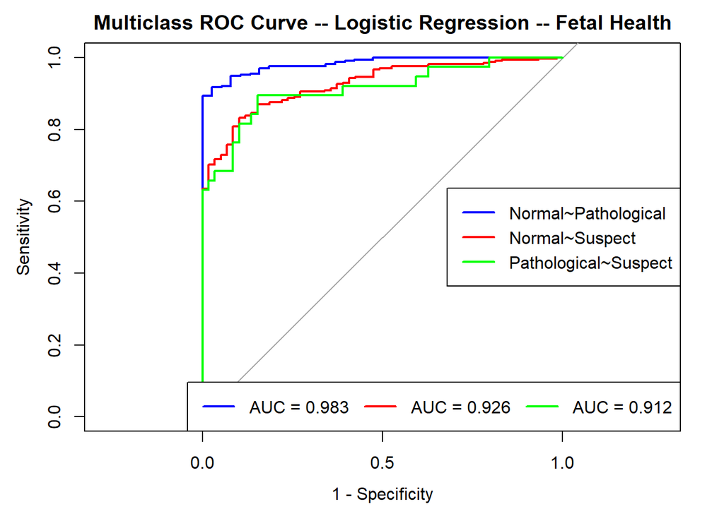

```r
# Plot each of the curves, overlayed with one another
plot.roc(rs[[1]][[2]], col = 'blue', legacy.axes = TRUE,
         main = "Multiclass ROC Curve -- Logistic Regression -- Fetal Health")
plot.roc(rs[[2]][[2]], col = 'red', add = TRUE)
plot.roc(rs[[3]][[2]], col = 'green', add = TRUE)

# Add legends for clarity
legend(x = "right",          # Position
       legend = c("Normal~Pathological",
                  "Normal~Suspect",
                  "Pathological~Suspect"),  # Legend texts
       lty = c(1, 1, 1),           # Line types
       col = c('blue', 'red', 'green'),           # Line colors
       lwd = 2)

legend(x = "bottomright",          # Position
       legend = c(paste("AUC =", round(AUC1, 3)),
                  paste("AUC =", round(AUC2, 3)),
                  paste("AUC =", round(AUC3, 3))),  # Legend texts
       lty = c(1, 1, 1),           # Line types
       col = c('blue', 'red', 'green'),           # Line colors
       lwd = 2,
       horiz = TRUE)
```

Beautiful! What a nice plot, despite being created with base R graphics. Now, on to the interpretation. The 45 degree diagonal line represents the curve that would occur if our model was a naive classifier. In other words, if our model made its predictions randomly. The other three lines are more interesting. Each one represents the ability of our model to distinguish between any given pair of classes. Since we have three classes, we’ll have three different pairings, thus three lines. The closer the lines are to reaching the top left corner of the plot, the better.

In general, it’s easier to summarize the performance of a model by calculating the area under the curve for each of the curves. These are shown in the bottom right legend, and the closer each value is to 1, the better. Our scores are all above .9, which indicates our model does a much better job at distinguishing between the classes in each pair than a naive, random model would.

This final metric, in combination with the previously discussed metric results, indicates that our model is successful enough at performing the task we assigned it.

### 14) Final Discussion

And there you have it! We have succesfully fit a multinomial logistic regression model to our fetal health data.

In summary we have:

- applied good modeling practices by creating a train-test data split,
- performed some exploratory data analysis,
- used a combination of under- and over-sampling to balance our response classes,
- addressed collinearity of our predictors via PCA,
- fit and evaluated a multinomial logistic regression model,
- and discussed the successes and shortcomings of our model.

I would like to see if my model would perform better without the PCA we applied, since I was unsure if it was completely necessary. There was some multicollinearity between the predictor variables, but maybe not enough to merit PCA.

Instead of PCA, I could have performed hypothesis tests to tell which of my predictors were significant in the model, and sequentially remove (backward selection) or add (forward selection) predictors. This also would have afforded the opportunity to interpret the model’s coefficient estimates, since their original meaning would not have been obscured by the dimensionality reduction.

**If you have any recommendations on how to improve this work, questions, or other comments, please let me know!**

**Thanks for reading!**